# hw2-Gapminder Exploratory Data Analysis

Irfan Ainuddin

9/6/2019

## 1.1 Loading and Looking

Load the Gapminder data .

```r
## Loading in the gapminder library which contains the data to be explored in this exercise.


## library("gapminder")
```

Load the tidyverse to work with data.

```r
## Loading in the complete tidyverse package (which has extra tools we wont use) to begin exploratory data analysis (EDA) of the gapminder datased loaded above.


## library("tidyverse")
```

Look at the structure of the gapminder data set.

```r
## Inspect the structure of the data with the str() function.

str(gapminder)
```

```
## Classes 'tbl_df', 'tbl' and 'data.frame':    1704 obs. of  6 variables:
##  $ country  : Factor w/ 142 levels "Afghanistan",..: 1 1 1 1 1 1 1 1 1 1 ...
##  $ continent: Factor w/ 5 levels "Africa","Americas",..: 3 3 3 3 3 3 3 3 3 3 ...
##  $ year     : int  1952 1957 1962 1967 1972 1977 1982 1987 1992 1997 ...
##  $ lifeExp  : num  28.8 30.3 32 34 36.1 ...
##  $ pop      : int  8425333 9240934 10267083 11537966 13079460 14880372 12881816 13867957 16317921 22227415 ...
##  $ gdpPercap: num  779 821 853 836 740 ...
```

```r
##  Display the first 6 values of the data set with the head() function.

head(gapminder)
```

```
## # A tibble: 6 x 6
##   country     continent  year lifeExp      pop gdpPercap
##   <fct>       <fct>     <int>   <dbl>    <int>     <dbl>
## 1 Afghanistan Asia       1952    28.8  8425333      779.
## 2 Afghanistan Asia       1957    30.3  9240934      821.
## 3 Afghanistan Asia       1962    32.0 10267083      853.
## 4 Afghanistan Asia       1967    34.0 11537966      836.
## 5 Afghanistan Asia       1972    36.1 13079460      740.
## 6 Afghanistan Asia       1977    38.4 14880372      786.
```

The gapminder data set includes 6 variables (columns) with 1704 observations (rows).

The variables included are: country, continent, year, lifeExp, pop, gdpPercap.

country, and continent are factors (categorical variables), year and pop are integers (whole numbers) and lifeExp and gdpPercap are numbers (numbers with decimal places).

## 1.2 Goal Setting

The idea is to take a large data set with complexity and break it down into component parts. In this case, we have continents which contain countries which have a population with a life expectancy that was determined over some period of time.

I would like to be able to investigate the variation of lifeExp and population between different countries within a specific continent for the years in which the data is available.

## 1.3 Inspect the variation within the variables

```r
## Call the summary() function on the year variable to see the range of years data is available

summary(gapminder$year)
```

```
##    Min. 1st Qu.  Median    Mean 3rd Qu.    Max.
##    1952    1966    1980    1980    1993    2007
```

```r
table(gapminder$year)
```

```
##
## 1952 1957 1962 1967 1972 1977 1982 1987 1992 1997 2002 2007
##  142  142  142  142  142  142  142  142  142  142  142  142
```

The years range from 1952 to 2007, however, the table shows us there are only 12 years of that range which data was collected. In this case, while the variable is an int, it sort of acts as a factor (categorical variable).

```r
## Call the summary() function on the pop variable

summary(gapminder$pop)
```

```
##      Min.   1st Qu.    Median      Mean   3rd Qu.      Max.
## 6.001e+04 2.794e+06 7.024e+06 2.960e+07 1.959e+07 1.319e+09
```

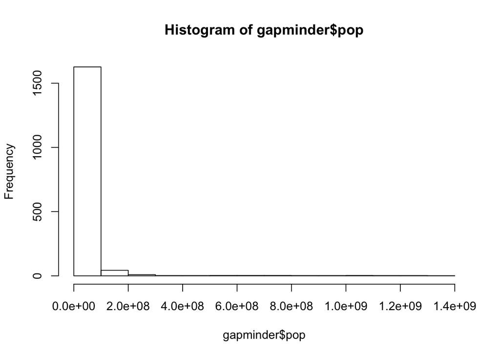

```r
## Call the hist() function to view the population distributions
hist(gapminder$pop)
```

The range in population is quite large from 6.001e+04 to 1.319e+09, considering sthe scale range of values suggests exponential changes in population. We may need to apply a logarithmic scale to visualize population data in a linear relationship with other variables. A quick look at the histogram shows the frequency of observations, since we know populations belong to each country

```r
## Call the summary() function on the lifeExp variable

summary(gapminder$lifeExp)
```

```
##    Min. 1st Qu.  Median    Mean 3rd Qu.    Max.
##   23.60   48.20   60.71   59.47   70.85   82.60
```

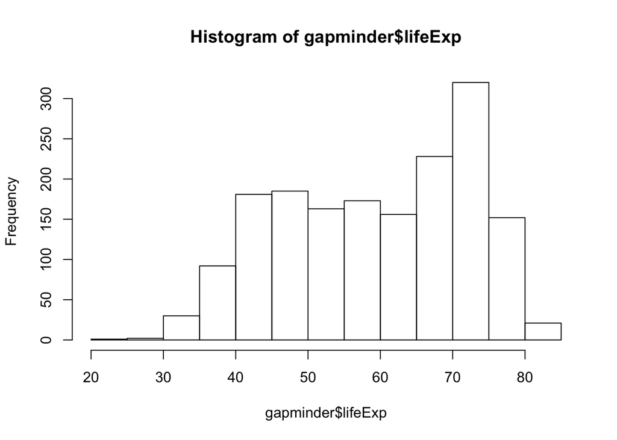

```r
## Call the hist() to view the life expectency distribution
hist(gapminder$lifeExp)
```

```r
## Call the table() function on the continent variable in the gapminder dataset to count the number of observations recorded for each continent.

table(gapminder$continent)
```

```
##
##   Africa Americas     Asia   Europe  Oceania
##      624      300      396      360       24
```

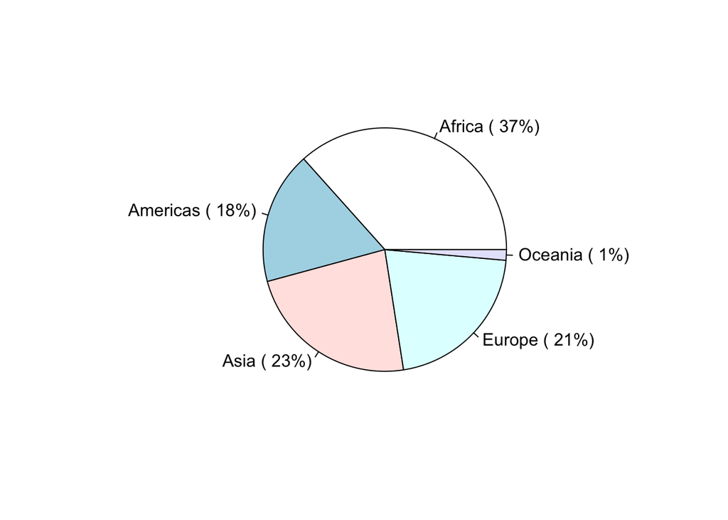

```r
## Use a pie chart to show the distrubution of observations in africa

conts <- table(gapminder$continent)

pie(conts, labels =paste0(names(conts), ' ( ', round(prop.table(conts)*100), "%)"))
```

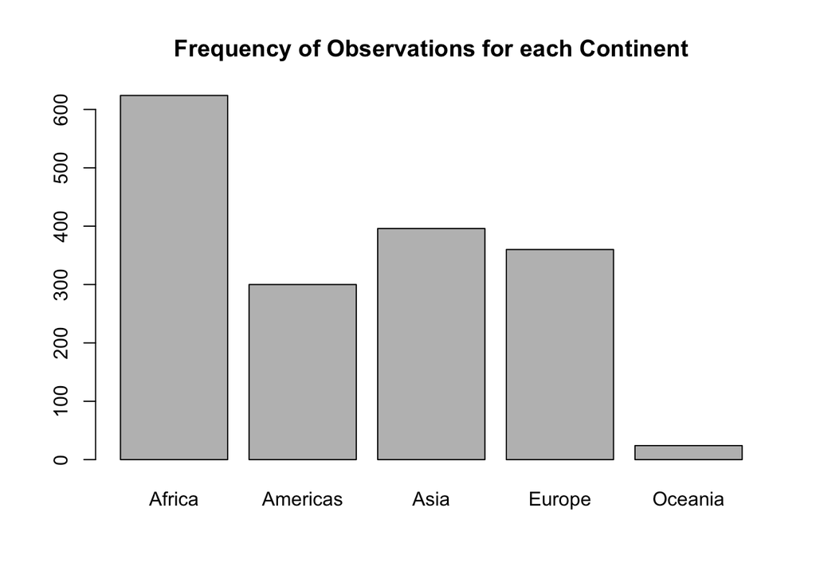

```r
## Use a barplot to do the same but better.

barplot(conts, main="Frequency of Observations for each Continent")
```

From the table we can see the number of observations for each country, Africa has the highest frequency (n = 624) and Oceania with the lowest frequencey (n = 24)

Since the goal is to be able to work with complex data and break it down into component parts, if I want to work with variations between countries it will be simpler to work with countries within a continent instead of all countries.

## 1.4 Utilizing tidyverse for EDA

```r
## Explore how many countries are represented in each continent, using pipes %>% and group_by(), n() and n_distinct()
gapminder %>%
  group_by(continent) %>%
  summarise( n = n(),
             n_countries = n_distinct(country))
```

```
## # A tibble: 5 x 3
##   continent     n n_countries
##   <fct>     <int>       <int>
## 1 Africa      624          52
## 2 Americas    300          25
## 3 Asia        396          33
## 4 Europe      360          30
## 5 Oceania      24           2
```

From the table produced we can see the number of observations (n) and the number of unique countries (n_countries) for each continent with a high of 52 in Africa and a low of 2 in Oceania.

#### What is the relationship between life expectancy and gdp over time?

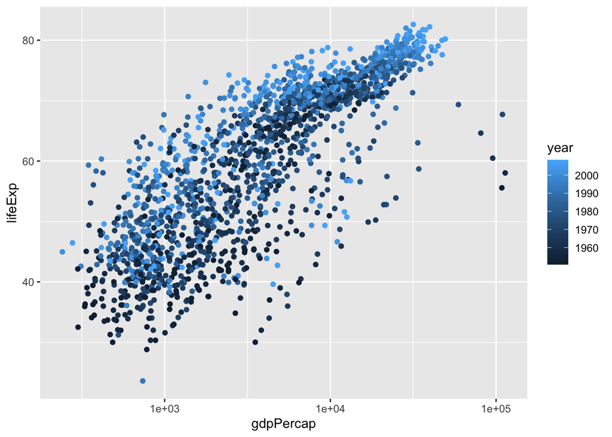

```r
p <- ggplot(gapminder, aes(x=gdpPercap, y=lifeExp, color = year)) # initialize ggplot with data
p <- p + scale_x_log10() # add log scale to x axis for gdpPercap
p + geom_point()
```

Based on the color distributions it seems that life exptency is increasing over time. Looks like a positive linear relationship between gdpPercap and lifeExp, lets add a trend line.

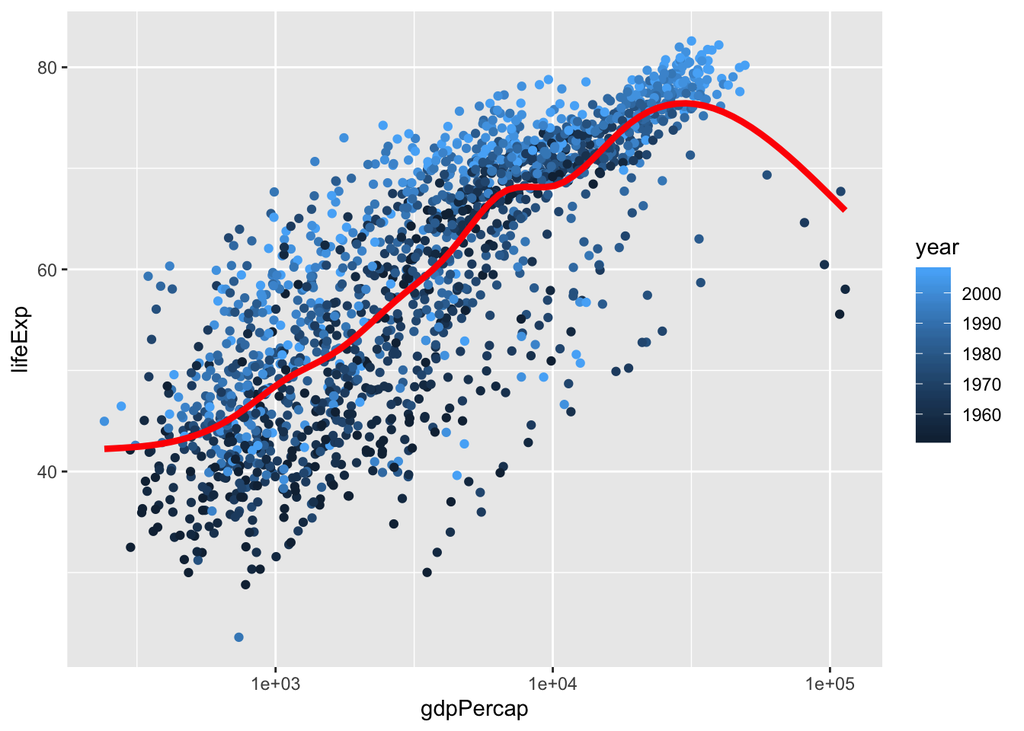

```r
p + geom_point() + geom_smooth(lwd = 1.5, se = FALSE, color = "red")
```

Hmm… there seems to be a drop off at the high gdpPercap range due to some covariation with years in 1960? lets try disentangling the data with facet-wraapping by year.

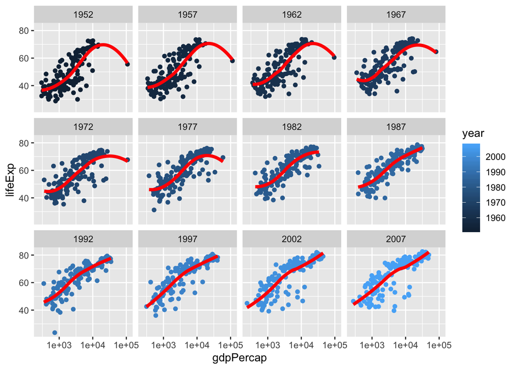

```r
p + geom_point() + geom_smooth(lwd = 1.5, se = FALSE, color = "red") + facet_wrap(~ year)
```

#### An outlier of interest has been spotted!!!!

It seems as though the positive relationship between lifeExp and gdp improved over time. The improvement in the relationships seems to be due to a consistent outlier point. That specific country could be interesting.

It is a country with the highest GDP but has an average life expectancy… at some point between 1977 and 1982 that changes..Maybe there was a large shift in policy or government?

Lets recreate the same graph but this time we will color by continents with 1 explicit code chunk.

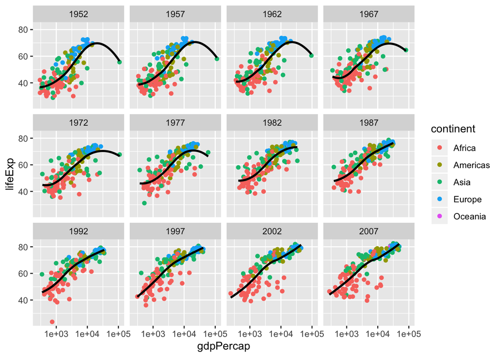

```r
p <- ggplot(gapminder, aes(x=gdpPercap, y=lifeExp, color = continent)) # initialize ggplot with data
p <- p + scale_x_log10() # add log scale to x axis for gdpPercap
p + geom_point() + geom_smooth(lwd = 1, se = FALSE, color = "black") + facet_wrap(~ year)
```

When we color by continents we see that the outlier country is in Asia, so lets subset our data and see if we can isolate that country.

```r
## create subset of the continent asia
asia <- gapminder %>%
  filter(continent == "Asia")

asia %>% group_by(country)
```

```
## # A tibble: 396 x 6
## # Groups:   country [33]
##    country     continent  year lifeExp      pop gdpPercap
##    <fct>       <fct>     <int>   <dbl>    <int>     <dbl>
##  1 Afghanistan Asia       1952    28.8  8425333      779.
##  2 Afghanistan Asia       1957    30.3  9240934      821.
##  3 Afghanistan Asia       1962    32.0 10267083      853.
##  4 Afghanistan Asia       1967    34.0 11537966      836.
##  5 Afghanistan Asia       1972    36.1 13079460      740.
##  6 Afghanistan Asia       1977    38.4 14880372      786.
##  7 Afghanistan Asia       1982    39.9 12881816      978.
##  8 Afghanistan Asia       1987    40.8 13867957      852.
##  9 Afghanistan Asia       1992    41.7 16317921      649.
## 10 Afghanistan Asia       1997    41.8 22227415      635.
## # … with 386 more rows
```

```r
head(asia)
```

```
## # A tibble: 6 x 6
##   country     continent  year lifeExp      pop gdpPercap
##   <fct>       <fct>     <int>   <dbl>    <int>     <dbl>
## 1 Afghanistan Asia       1952    28.8  8425333      779.
## 2 Afghanistan Asia       1957    30.3  9240934      821.
## 3 Afghanistan Asia       1962    32.0 10267083      853.
## 4 Afghanistan Asia       1967    34.0 11537966      836.
## 5 Afghanistan Asia       1972    36.1 13079460      740.
## 6 Afghanistan Asia       1977    38.4 14880372      786.
```

Ok, so now we have asia, which has 396 observations, 12 observations for each country and we know the outlier data points are before 1982 so lets create a filter to find the country before 1982 with the highest GDPpercap.

```r
## filter for years before 1982, and find the country with the highest GDPperCapipta and that should be our country of interest.

target <- asia %>%
  filter(year < 1982) %>%
  group_by(country) %>%
  summarise(n = n(),
            maxGDP = max(gdpPercap),
             n_countries = n_distinct(country))


## arrange() by desc() should bring our target country to the top.
arrange(target, desc(maxGDP))
```

```
## # A tibble: 33 x 4
##    country              n  maxGDP n_countries
##    <fct>            <int>   <dbl>       <int>
##  1 Kuwait               6 113523.           1
##  2 Saudi Arabia         6  34168.           1
##  3 Bahrain              6  19340.           1
##  4 Japan                6  16610.           1
##  5 Iraq                 6  14688.           1
##  6 Israel               6  13307.           1
##  7 Iran                 6  11889.           1
##  8 Oman                 6  11848.           1
##  9 Singapore            6  11210.           1
## 10 Hong Kong, China     6  11186.           1
## # … with 23 more rows
```

So our potential country of interest is Kuwait, which immediatly offers insight to the High GDP to life expectency relationship before 1982 and why it may have improved or “normalized” since then……..Any idea on what exactly makes this relationship in Kuwait so interesting?? My bet are on OIL.

A small developing country with massive oil reserves and has experienced a lot of political change and upheavel.

Lets take a closer look at Kuwait!

```r
## create kuwait subset

kuwait <- gapminder %>%
  filter(country == "Kuwait")

## inspect kuwait

str(kuwait)
```

```
## Classes 'tbl_df', 'tbl' and 'data.frame':    12 obs. of  6 variables:
##  $ country  : Factor w/ 142 levels "Afghanistan",..: 72 72 72 72 72 72 72 72 72 72 ...
##  $ continent: Factor w/ 5 levels "Africa","Americas",..: 3 3 3 3 3 3 3 3 3 3 ...
##  $ year     : int  1952 1957 1962 1967 1972 1977 1982 1987 1992 1997 ...
##  $ lifeExp  : num  55.6 58 60.5 64.6 67.7 ...
##  $ pop      : int  160000 212846 358266 575003 841934 1140357 1497494 1891487 1418095 1765345 ...
##  $ gdpPercap: num  108382 113523 95458 80895 109348 ...
```

```r
## Why do all factor levels get saved into the new DF object? Do tibbles fix this?
```

#### QUESTION:

I was having a huge problem with this trying to subset asia and make nice looking tables with just the countries in asia.

Stat545 has a discussion talks about tables, tibles, and dataframes here: https://stat545.com/block010_dplyr-end-single-table.html#group_by-is-a-mighty-weapon

#### Moving on… A closer look at Kuwait

Lets inspect the trends in GDP per capita from the 1950s to the 2000s.

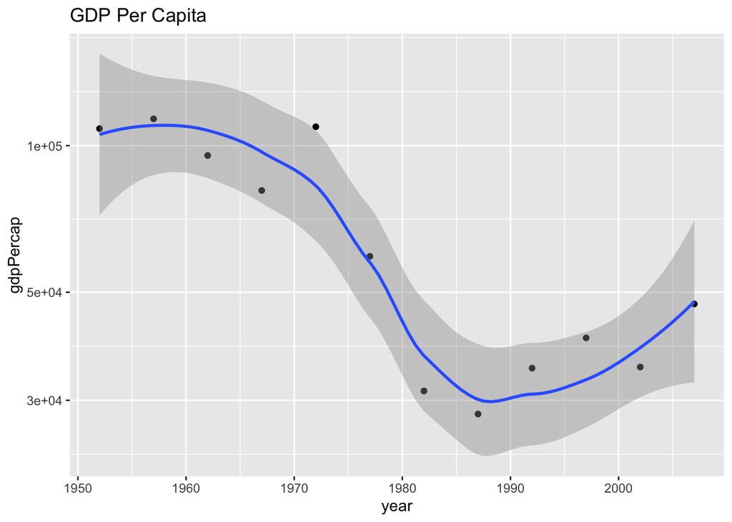

```r
## Check out GDP over time

k <- ggplot(kuwait, aes(x=year, y=gdpPercap))
k <- k + scale_y_log10() # add log scale to y axis for gdpPercap
k + geom_point() + ggtitle("GDP Per Capita") +geom_smooth()
```

GDP per captia seems to drop drastically during the 1970s to a low in the Late 80’s around the time of the Gulf War.

Lets take a look at Kuwait’s change in population over the same time frame.

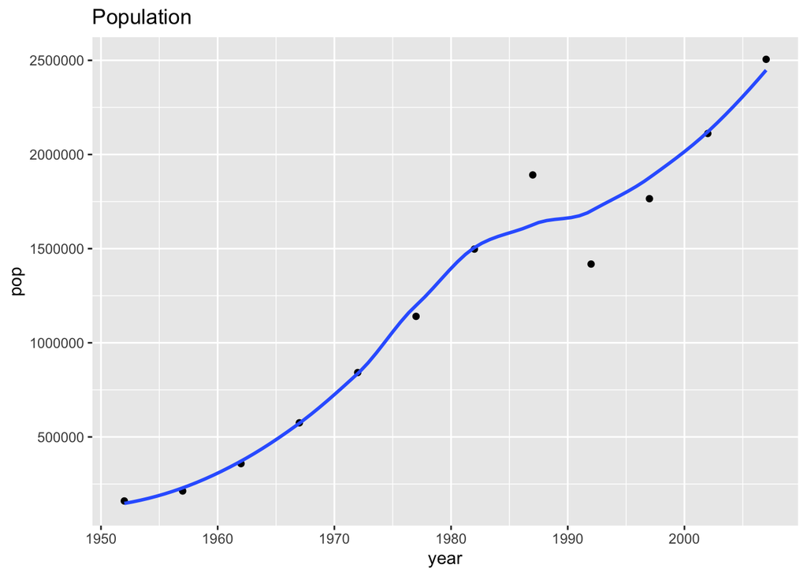

```r
## Check out population over time

k1 <- ggplot(kuwait, aes(x=year, y=pop))
k1 + geom_point() + ggtitle("Population") +geom_smooth(se = FALSE)
```

It Looks like Kuwait’s population is growing substantially.

Lets take a look at the life expectancy of Kuwait’s growing population.

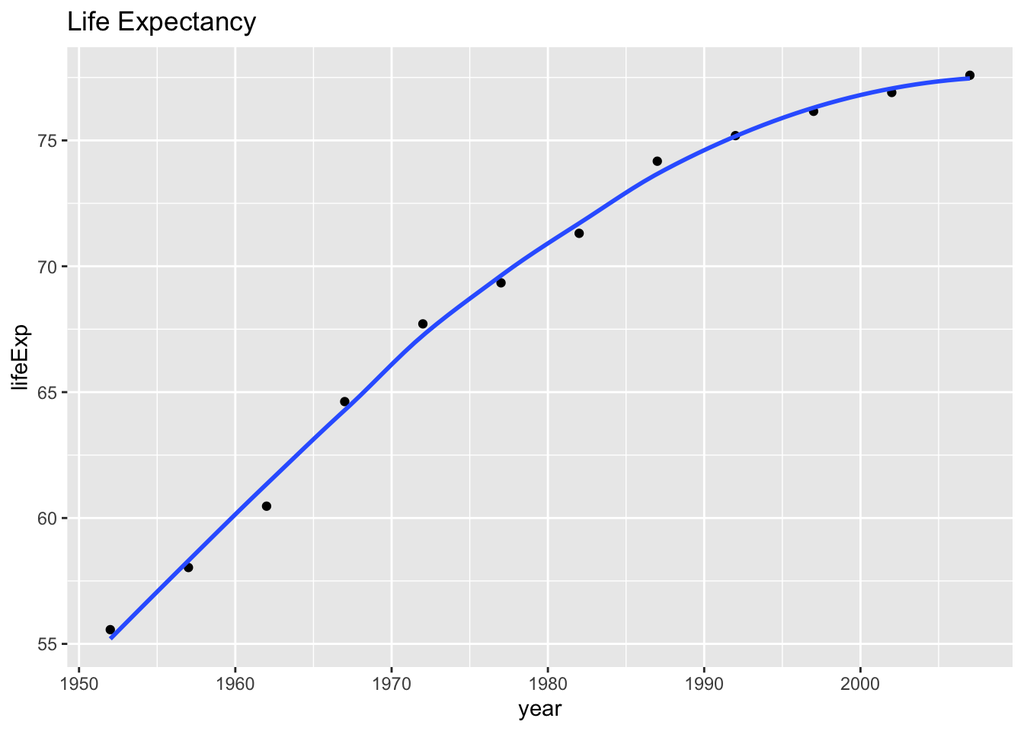

```r
## Check out life expectancy over time

k2 <- ggplot(kuwait, aes(x=year, y=lifeExp))
k2 + geom_point() + ggtitle("Life Expectancy") +geom_smooth(se = FALSE)
```

It looks like Kuwaits population is living longer and longer but starting to level off a bit around 80 years old.

So, the story is that Kuwait’s population is growing and living longer while the GDP per capita is shrinking suggests even though more people exist in the country and are living longer, they may not necessarily be contributing very much to the countries overall GDP. Knowing that Kuwait is an oil producing nation and apart of OPEC we can start to form a questions and hypotheses investigate just how much of an influence the population has on kuwaits GDP per Capita through statistical analysis.

Lets get back to the first bi-variate relationship we explored for all the countries in this data set,which started us down this rabbit hole, the relationship between GDP per capita and life expectency specifically for Kuwait.

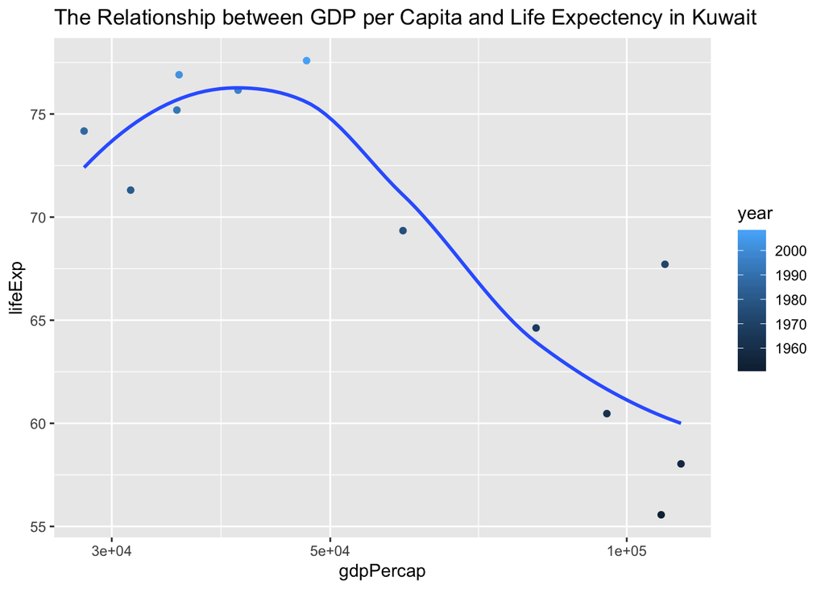

```r
k3 <- ggplot(kuwait, aes(x=gdpPercap, y=lifeExp, color = year))
k3 <- k3 + scale_x_log10() # add log scale to x axis for gdpPercap
k3 + geom_point() + ggtitle("The Relationship between GDP per Capita and Life Expectency in Kuwait") + geom_smooth(se = FALSE)
```

We see the same cluster of dark blue data points that peaked our interest from our original visualization of the variables lifeExp and gdpPercap for the entire gapminder dataset in an isolated state.

## 1.5 EDA Success!!

We have successfully drilled down through the gapminder dataset using methods of exploratory data analysis driven by visualizations to explore areas of interest within the dataset and formulate new questions and hypothesis.